# Writeup

tt

Friday, September 19, 2014

**This is the submission for Practical Machine Learning - Prediction Assignment**

##### Load data

- Let us load both our training and testing groupware files that are downloaded from coursera
- Do the initial cleanup by setting na values to what we have seen in these files, especially train data

```r
trainData = read.csv("pml-training.csv", na.strings=c("", "NA", "NULL"))
testData = read.csv("pml-testing.csv", na.strings=c("", "NA", "NULL"))

dim(trainData)
```

```
## [1] 19622   160
```

- Based on preliminary analysis, there are a lot of columns that will not add any value to our predictions
- They include columns that are very sparse (dense with na values), fillers (X), timestamps, window vars
- Let us clean them out!
- First, let us remove any column that is not at least 90% populated

```r
trainData <- trainData[,colSums(is.na(trainData))< 0.9*nrow(trainData)]
```

- Next, let us remove non value add columns like timestamps, window columns and user names

```r
nonValueAddColumns = c('raw_timestamp_part_1', 'raw_timestamp_part_2', 'cvtd_timestamp', 'new_window', 'num_window', 'X', 'user_name')
trainData <- trainData[, -which(names(trainData) %in% nonValueAddColumns)]
dim(trainData)
```

```
## [1] 19622    53
```

- Great! Now we trimmed the file down from 160 columns to a mere 53
- Let us load the required libraries
- Set our seed for reproducability

```r
library(caret)
library(rpart)
library(randomForest)
library(ElemStatLearn)
library(corrplot)
set.seed(100)
```

- Let us apply the random forest and lda models for our classe variable to check for comparison
- Note: gbm was taking too long so we are sticking to these two models for comparison

```r
partScheme <- createDataPartition(y=trainData$classe, p=0.6, list=FALSE)
trainPartition <- trainData[partScheme,]
testPartition <- trainData[-partScheme,]

#gbmModel <- train(classe ~ ., data=trainPartition, method="gbm")
ldaModel <- train(classe ~ ., data=trainPartition, method="lda")
rfModel <- randomForest(classe~.,data=trainPartition)
#importance(ldaModel)
#importance(rfModel)

#gbmPred <- predict(gbmModel, testPartition)
ldaPred <- predict(ldaModel, testPartition)
rfPred <- predict(rfModel, testPartition)

#confusionMatrix(gbmPred, testPartition$classe)
confusionMatrix(ldaPred, testPartition$classe)
```

```
## Confusion Matrix and Statistics
##
##           Reference
## Prediction    A    B    C    D    E
##          A 1792  231  115   71   43
##          B   48  960  131   58  259
##          C  211  181  925  140  114
##          D  177   67  166  971  156
##          E    4   79   31   46  870
##
## Overall Statistics
##
##                Accuracy : 0.703
##                  95% CI : (0.693, 0.713)
##     No Information Rate : 0.284
##     P-Value [Acc > NIR] : <2e-16
##
##                   Kappa : 0.625
##  Mcnemar's Test P-Value : <2e-16
##
## Statistics by Class:
##
##                      Class: A Class: B Class: C Class: D Class: E
## Sensitivity             0.803    0.632    0.676    0.755    0.603
## Specificity             0.918    0.922    0.900    0.914    0.975
## Pos Pred Value          0.796    0.659    0.589    0.632    0.845
## Neg Pred Value          0.921    0.913    0.929    0.950    0.916
## Prevalence              0.284    0.193    0.174    0.164    0.184
## Detection Rate          0.228    0.122    0.118    0.124    0.111
## Detection Prevalence    0.287    0.186    0.200    0.196    0.131
## Balanced Accuracy       0.860    0.777    0.788    0.834    0.789
```

```r
confusionMatrix(rfPred, testPartition$classe)
```

```
## Confusion Matrix and Statistics
##
##           Reference
## Prediction    A    B    C    D    E
##          A 2230    7    1    0    0
##          B    2 1505    9    0    0
##          C    0    6 1353   17    2
##          D    0    0    5 1269    6
##          E    0    0    0    0 1434
##
## Overall Statistics
##
##                Accuracy : 0.993
##                  95% CI : (0.991, 0.995)
##     No Information Rate : 0.284
##     P-Value [Acc > NIR] : <2e-16
##
##                   Kappa : 0.991
##  Mcnemar's Test P-Value : NA
##
## Statistics by Class:
##
##                      Class: A Class: B Class: C Class: D Class: E
## Sensitivity             0.999    0.991    0.989    0.987    0.994
## Specificity             0.999    0.998    0.996    0.998    1.000
## Pos Pred Value          0.996    0.993    0.982    0.991    1.000
## Neg Pred Value          1.000    0.998    0.998    0.997    0.999
## Prevalence              0.284    0.193    0.174    0.164    0.184
## Detection Rate          0.284    0.192    0.172    0.162    0.183
## Detection Prevalence    0.285    0.193    0.176    0.163    0.183
## Balanced Accuracy       0.999    0.995    0.993    0.993    0.997
```

- Let us check the accuracy of our random forest model

```r
accuracy<-c(as.numeric(predict(rfModel,newdata=testPartition[,-ncol(testPartition)])==testPartition$classe))
accuracy<-sum(accuracy)*100/nrow(testPartition)
print(accuracy)
```

```
## [1] 99.3
```

- Well. Random Forest does a better job at nonlinear features. So as can be expected, its accuracy is **99.299%!!**
- Let us check the accuracy of lda model

```r
accuracy<-c(as.numeric(predict(ldaModel,newdata=testPartition[,-ncol(testPartition)])==testPartition$classe))
accuracy<-sum(accuracy)*100/nrow(testPartition)
print(accuracy)
```

```
## [1] 70.33
```

- Well. We did not really expect it to be that low but the lda accuracy is **70.3288%!!**
- Let us check a couple of aspects of our random forest model
- First, let us see what the important features are based on the model we generated. Here are te top 10.

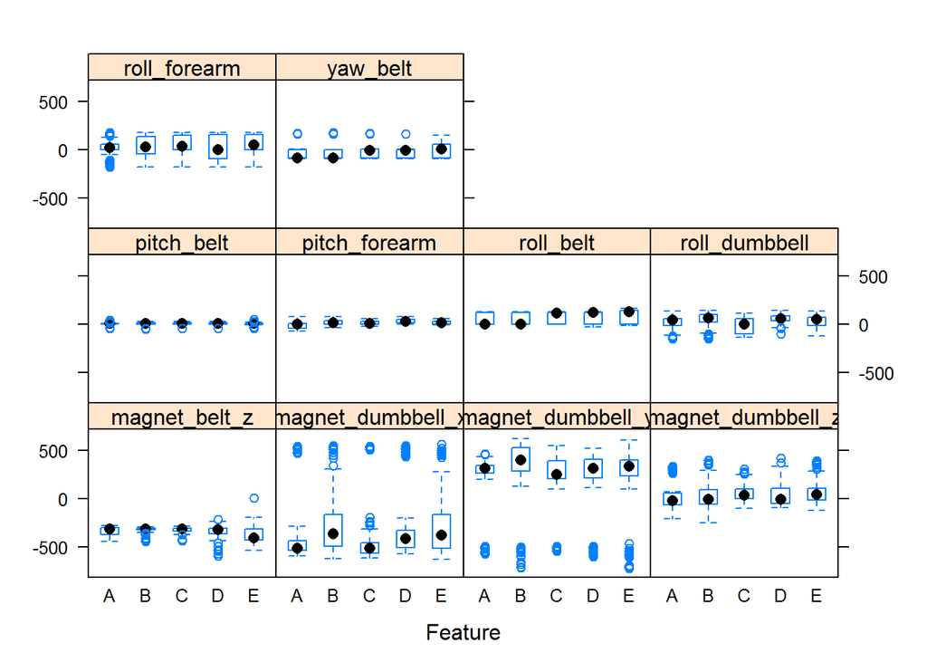

```r
randomForestImportance = data.frame(rfModel$importance)
topFeatures = order(-randomForestImportance$MeanDecreaseGini)
inImportant = createDataPartition(trainPartition$classe, p = 0.05, list = F)
featurePlot(trainPartition[inImportant,topFeatures[1:10]],trainPartition$classe[inImportant], plot = "box")
```

- Let us check the correlation of various variables in our training set

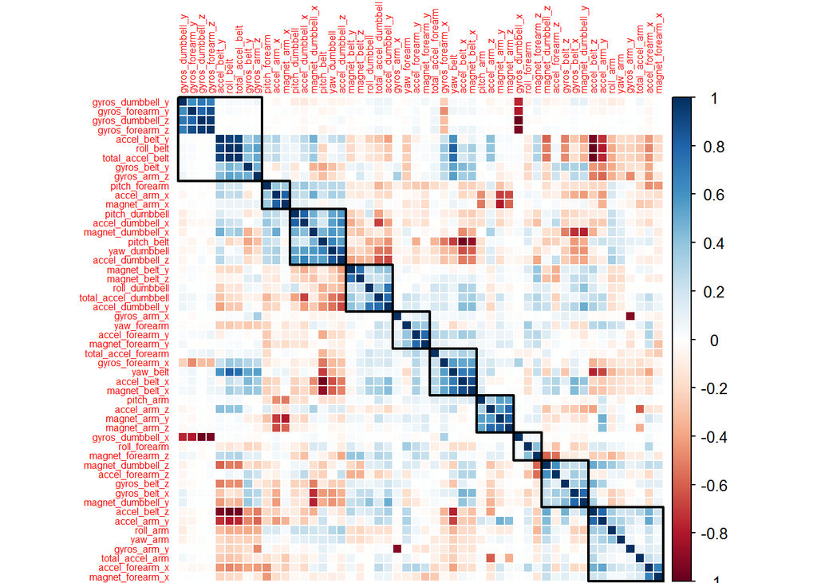

```r
correlationData <- cor(subset(trainPartition, select=-c(classe)))
corrplot(correlationData, order="hclust", tl.cex=0.5, method="color", insig = "pch", addrect = 10)
```

- Everything seems to be in line with the rfModel being the best approach to go
- Now let us predict using our model against the test dataset with rf model as its accuracy rate is higher than the lda model

```r
testData <- testData[,-1] # Remove the ID column
predictions <- predict(rfModel,newdata=testData) #Let us predict away!
print(predictions)
```

```
##  1  2  3  4  5  6  7  8  9 10 11 12 13 14 15 16 17 18 19 20
##  B  A  B  A  A  E  D  B  A  A  B  C  B  A  E  E  A  B  B  B
## Levels: A B C D E
```

- Last, but not the least, let us generate the answer files to submit for our assignment using the code provided along with the assignment.

```r
pml_write_files = function(x){
  n = length(x)
  for(i in 1:n){
    filename = paste0("./answers/problem_id_",i,".txt")
    write.table(x[i],file=filename,quote=FALSE,row.names=FALSE,col.names=FALSE)
  }
}

pml_write_files(predictions)
```

- Thats it! We are done with the assignment.